# Class08 try at home

Alicia Pacheco

October 31, 2018

## K-means clustering

Our first example with k-means

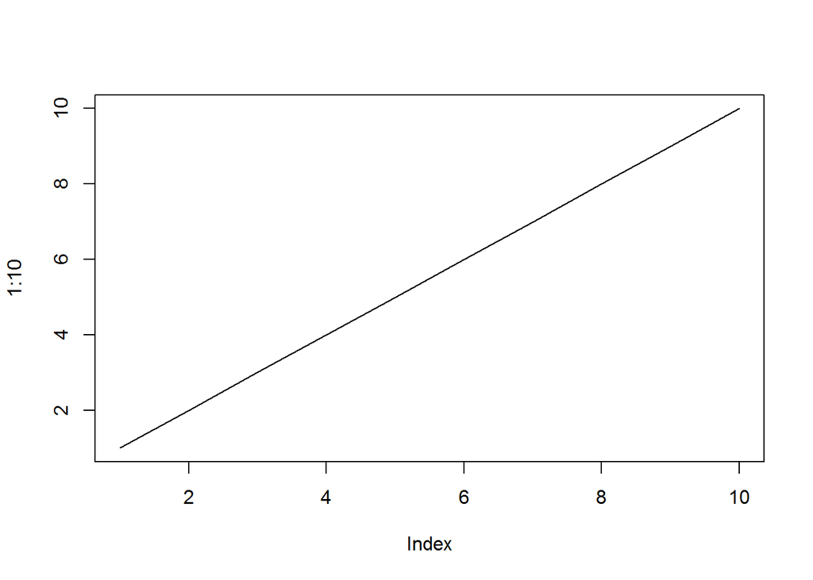

```r
#Example plot see how R markdown works
plot(1:10,type="l")
```

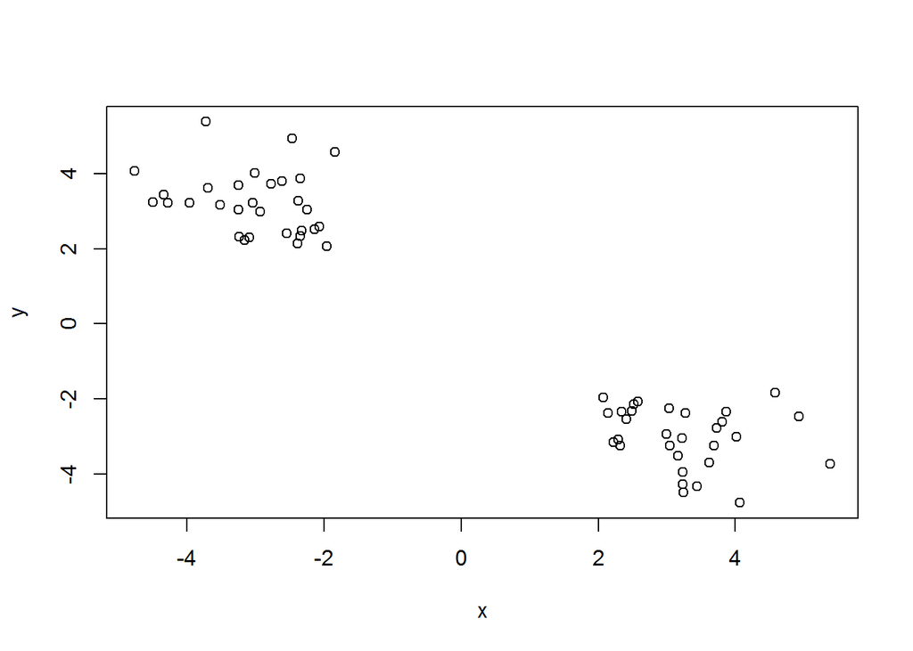

```r
#generate some example data for clustering
tmp <- c(rnorm(30,-3), rnorm(30,3))
x <- cbind(x=tmp, y=rev(tmp))
#And we plot
plot(x)
```

Using the *kmeans()* function setting k to 2 and nstart=20 Inspect/print the results

```r
k<-kmeans(x,centers=2,nstart=20)
```

How mant points are in each cluster?

```r
k$size
```

```
## [1] 30 30
```

Q. What ‘component’ of your result object details - cluster size `k$size`  
- cluster assignment/membership `k$cluster`  
- cluster center? `k$centers`

```r
#cluster size
k$size
```

```
## [1] 30 30
```

```r
#cluster assignement/membership
k$cluster
```

```
##  [1] 2 2 2 2 2 2 2 2 2 2 2 2 2 2 2 2 2 2 2 2 2 2 2 2 2 2 2 2 2 2 1 1 1 1 1
## [36] 1 1 1 1 1 1 1 1 1 1 1 1 1 1 1 1 1 1 1 1 1 1 1 1 1
```

```r
#cluster centers
k$centers
```

```
##           x         y
## 1  3.231671 -3.008007
## 2 -3.008007  3.231671
```

Plot x colored by the kmeans cluster assignment and add cluster centers as blue points

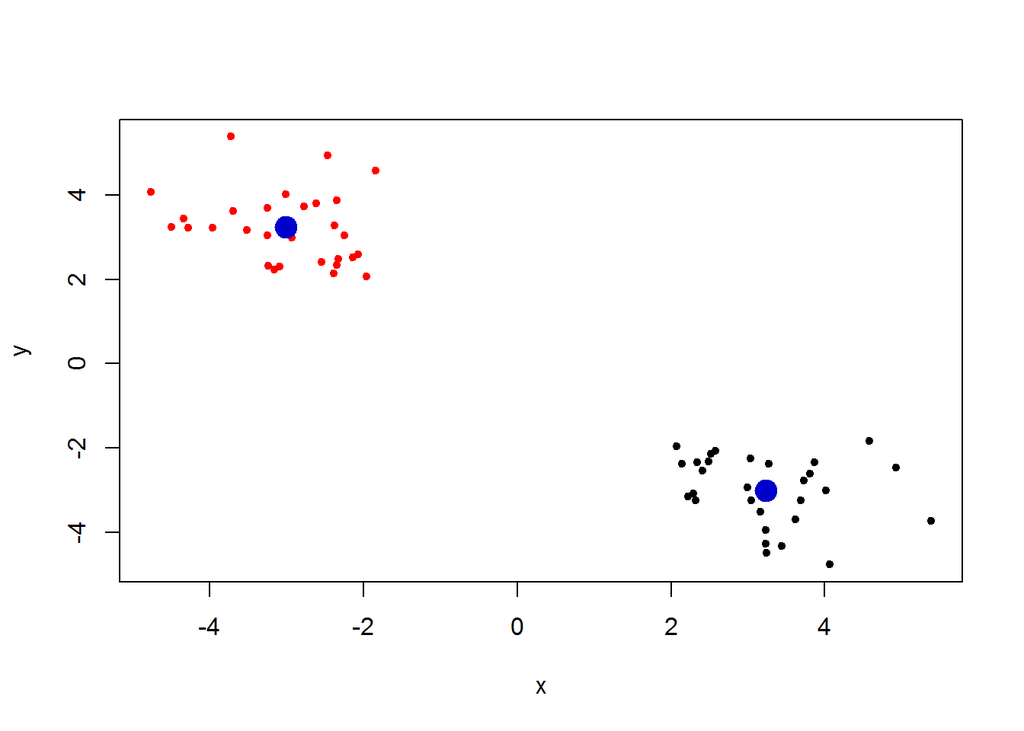

```r
plot(x, col=k$cluster,pch=20)
palette(c("black","red"))
points(k$centers,col="blue3",pch=20,cex=3)
```

Q. Repeat for k=3, which has the lower tot.withinss?

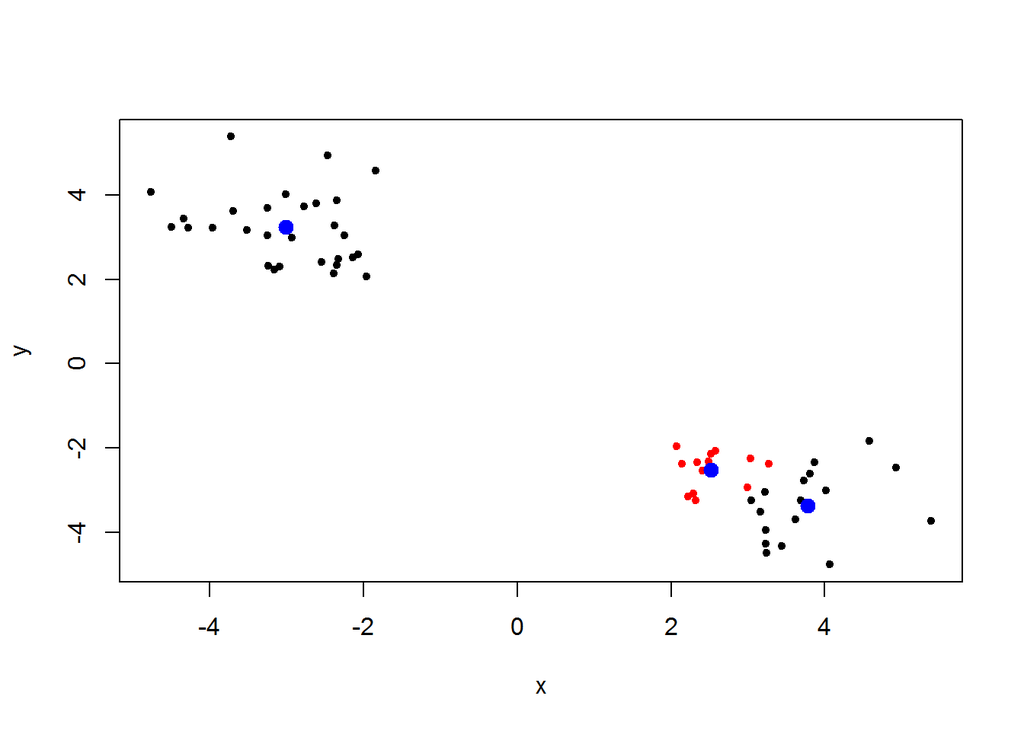

```r
k3<-kmeans(x,centers=3, nstart = 20)

plot(x,col=k3$cluster,pch=20)
palette(c("purple","red","black"))
points(k3$centers,col="blue",pch=20,cex=2)
```

```r
#total within cluster sum of squares, the smallest the petter
k$tot.withinss
```

```
## [1] 77.89623
```

```r
k3$tot.withinss
```

```
## [1] 60.78756
```

## Hierarchical CLustering

Create a hierarchical cluster model:hc

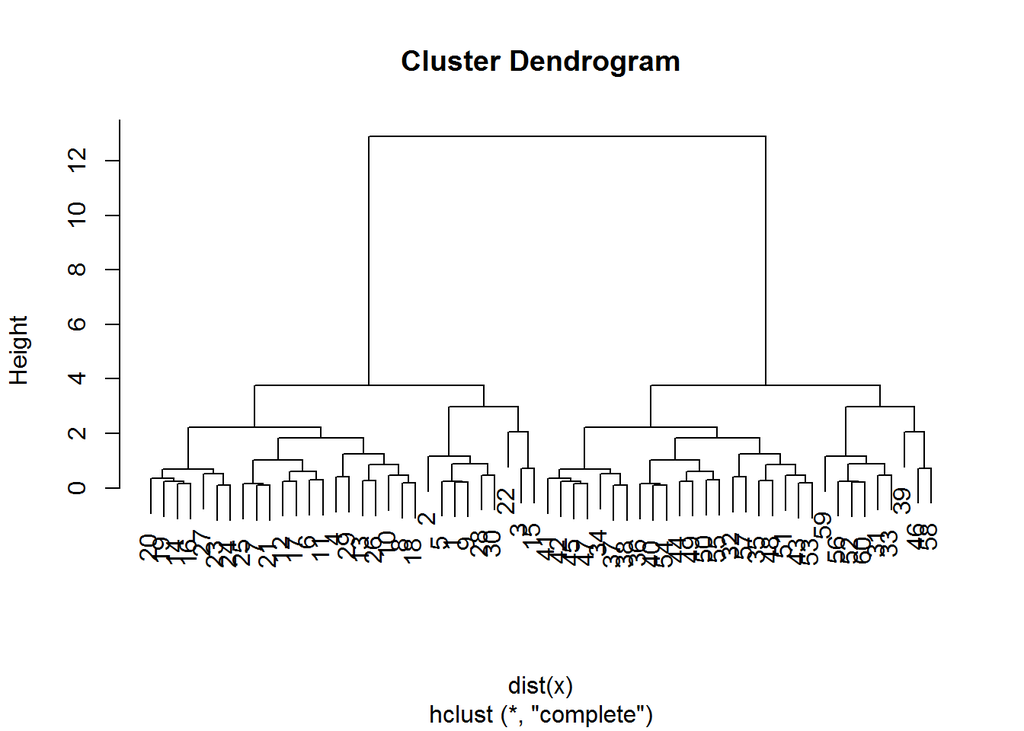

```r
hc<-hclust(dist(x))
plot(hc)
```

cutree

```r
cutree(hc,k=2)
```

```
##  [1] 1 1 1 1 1 1 1 1 1 1 1 1 1 1 1 1 1 1 1 1 1 1 1 1 1 1 1 1 1 1 2 2 2 2 2
## [36] 2 2 2 2 2 2 2 2 2 2 2 2 2 2 2 2 2 2 2 2 2 2 2 2 2
```

### A more real example

```r
# Step 1. Generate some example data for clustering
x <- rbind(
 matrix(rnorm(100, mean=0, sd = 0.3), ncol = 2), # c1
 matrix(rnorm(100, mean = 1, sd = 0.3), ncol = 2), # c2
 matrix(c(rnorm(50, mean = 1, sd = 0.3), # c3
 rnorm(50, mean = 0, sd = 0.3)), ncol = 2))

colnames(x) <- c("x", "y")
```

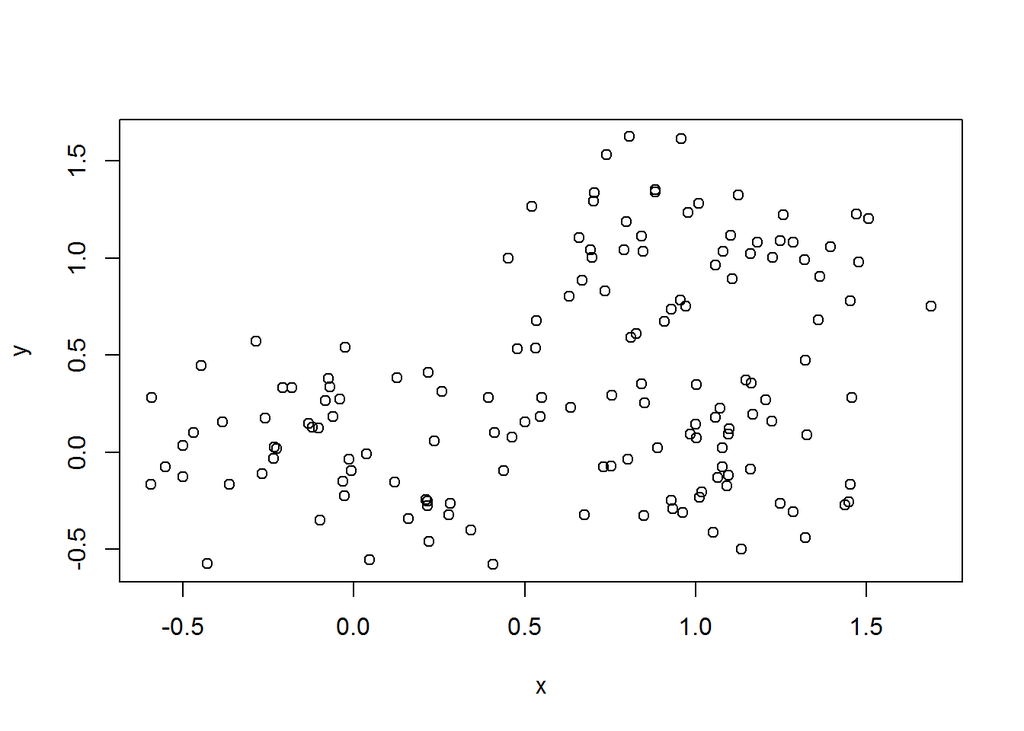

```r
# Step 2. Plot the data without clustering
plot(x)
```

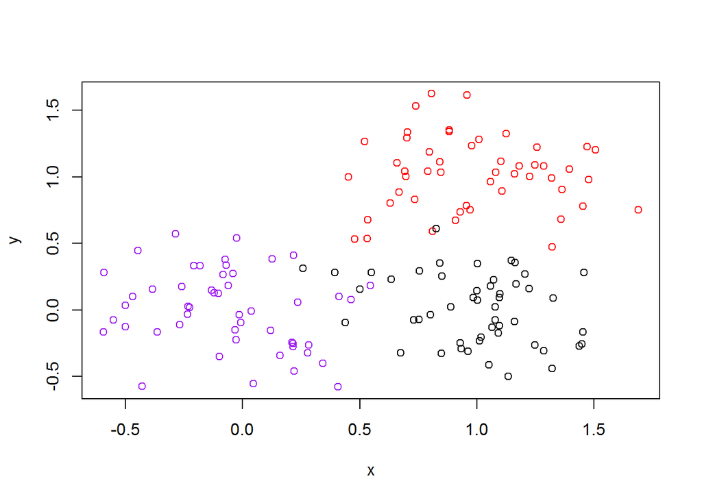

```r
# Step 3. Generate colors for known clusters
# (just so we can compare to hclust results)
col <- as.factor( rep(c("c1","c2","c3"), each=50) )
plot(x, col=col)
```

Q. Use the dist(), hclust(), plot() and cutree() functions to return 2 and 3 clusters

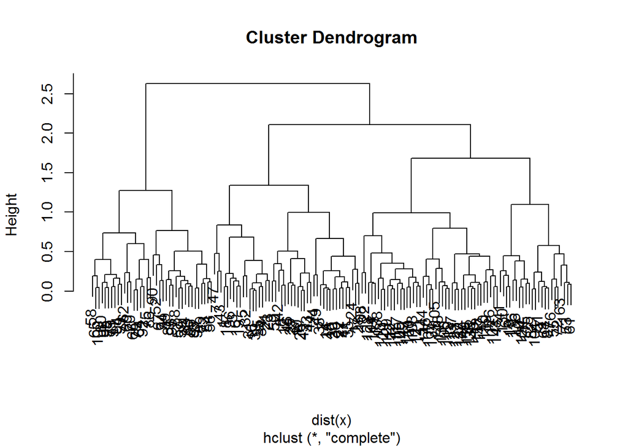

```r
hc<-hclust(dist(x))

plot(hc)
```

```r
cutree(hc,k=2)
```

```
##   [1] 1 1 1 1 1 1 1 1 1 1 1 1 1 1 1 1 1 1 1 1 1 1 1 1 1 1 1 1 1 1 1 1 1 1 1
##  [36] 1 1 1 1 1 1 1 1 1 1 1 1 1 1 1 1 2 1 2 1 2 2 2 2 2 1 2 1 2 2 2 2 1 2 2
##  [71] 1 1 2 2 2 1 1 2 2 2 2 1 2 2 2 2 1 2 2 2 2 2 2 2 2 2 2 2 2 2 1 1 1 1 1
## [106] 1 1 1 1 1 1 1 1 1 1 1 1 1 1 1 1 1 1 1 1 1 1 1 1 1 1 1 1 1 1 1 1 1 1 1
## [141] 1 1 1 1 1 1 1 1 1 1
```

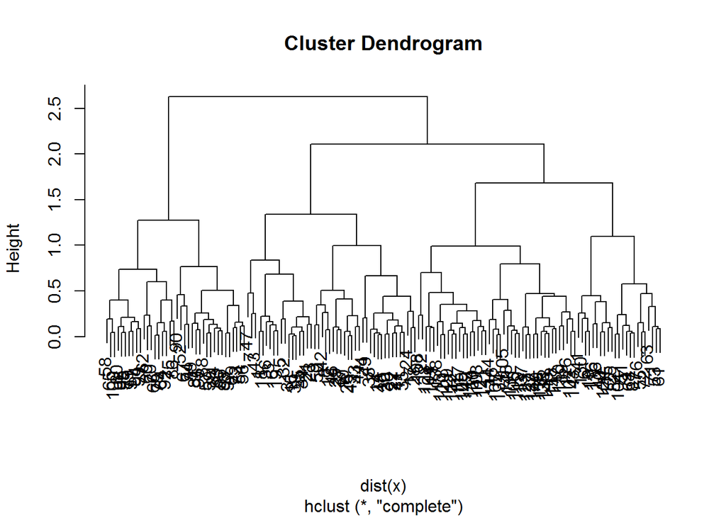

```r
hc<-hclust(dist(x))

plot(hc)
```

```r
cutree(hc,k=3)
```

```
##   [1] 1 1 1 1 1 2 1 1 1 1 1 1 2 1 1 1 1 1 1 1 1 1 1 1 1 1 1 1 1 1 1 1 1 1 1
##  [36] 1 1 1 1 2 2 1 1 1 1 1 1 1 1 1 2 3 2 3 2 3 3 3 3 3 2 3 2 3 3 3 3 2 3 3
##  [71] 2 2 3 3 3 2 2 3 3 3 3 2 3 3 3 3 2 3 3 3 3 3 3 3 3 3 3 3 3 3 2 2 2 2 2
## [106] 2 2 2 2 2 2 2 2 2 2 2 2 2 2 2 2 2 2 2 2 2 2 2 2 2 2 2 2 2 2 2 2 2 2 2
## [141] 2 2 2 2 2 2 2 2 2 2
```

## **PCA**

First lets generate some example data to work with.

```r
 #Initialize a blank 100 row by 10 column matrix
mydata <- matrix(nrow=100, ncol=10)
#Labeled the rows gene1, gene2, etc all the way to gene100

rownames(mydata)<-paste("gene",1:100,sep="")
#Label the columns with wt and ko
colnames(mydata)<-c(paste("wt",1:5,sep=""),paste("ko",1:5,sep=""))
head(mydata)
```

```
##       wt1 wt2 wt3 wt4 wt5 ko1 ko2 ko3 ko4 ko5
## gene1  NA  NA  NA  NA  NA  NA  NA  NA  NA  NA
## gene2  NA  NA  NA  NA  NA  NA  NA  NA  NA  NA
## gene3  NA  NA  NA  NA  NA  NA  NA  NA  NA  NA
## gene4  NA  NA  NA  NA  NA  NA  NA  NA  NA  NA
## gene5  NA  NA  NA  NA  NA  NA  NA  NA  NA  NA
## gene6  NA  NA  NA  NA  NA  NA  NA  NA  NA  NA
```

Fill in some facke read counts

```r
for(i in 1:nrow(mydata)) {
 wt.values <- rpois(5, lambda=sample(x=10:1000, size=1))
 ko.values <- rpois(5, lambda=sample(x=10:1000, size=1))

 mydata[i,] <- c(wt.values, ko.values)
}
```

Now we can do PCA

```r
#prcomp expects the samples to be the row and genes to be columns so we need to transose the matrix with the t()
pca<-prcomp(t(mydata),scale=TRUE)

#See atributes
attributes(pca)
```

```
## $names
## [1] "sdev"     "rotation" "center"   "scale"    "x"
##
## $class
## [1] "prcomp"
```

pca$ contains the principal components

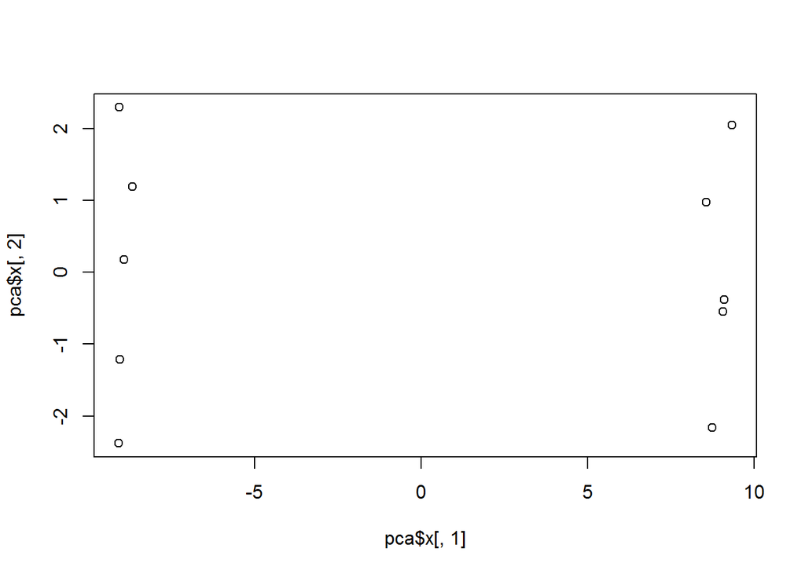

```r
plot(pca$x[,1],pca$x[,2])
```

variance captured per Pc

```r
#variance captured by PCA

pca.var <- pca$sdev^2
# Precent variance is often more informative to look at

pca.var.per <- round(pca.var/sum(pca.var)*100, 1)

pca.var.per
```

```
##  [1] 89.4  2.7  2.1  1.5  1.4  1.1  0.9  0.6  0.3  0.0
```

We can plot this

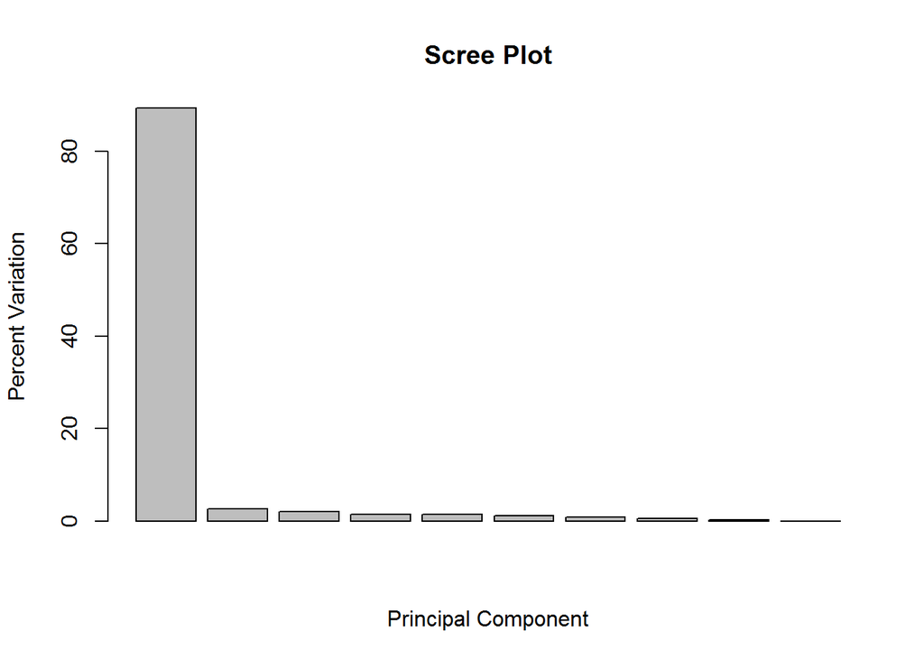

```r
barplot(pca.var.per, main="Scree Plot", xlab="Principal Component", ylab="Percent Variation")
```

```r
#This means that there are big differences between these two groups
```

We can add color to the vector

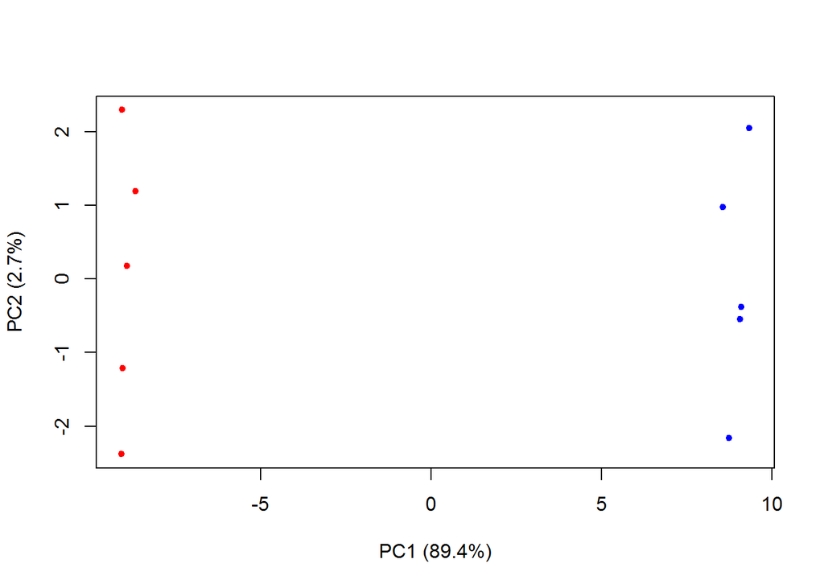

```r
colvec<-colnames(mydata)
colvec[grep("wt",colvec)]<-"red"
colvec[grep("ko",colvec)]<-"blue"

plot(pca$x[,1],pca$x[,2],col=colvec, pch=20,
     xlab=paste0("PC1 (", pca.var.per[1], "%)"),
     ylab=paste0("PC2 (", pca.var.per[2], "%)"))
```

We can identify the points

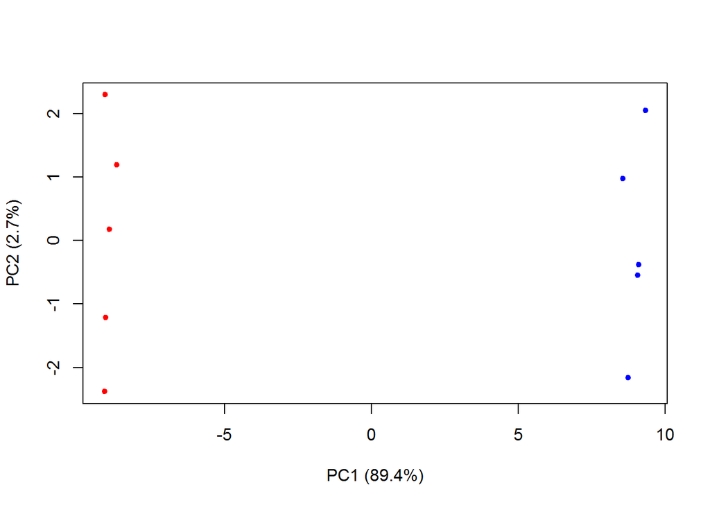

```
## integer(0)
```

```r
plot(pca$x[,1],pca$x[,2],col=colvec, pch=20,
     xlab=paste0("PC1 (", pca.var.per[1], "%)"),
     ylab=paste0("PC2 (", pca.var.per[2], "%)"))

identify(pca$x[,1],pca$x[,2],labels=colnames(mydata))
```

Finally we will use loading scores

```r
#loading scores help us deteremine which genes have the largest effect on where samples are pltted in the PCA plot
#prcomp() calls loading scores $rotation

loading_scores<-pca$rotation[,1]

summary(loading_scores)
```

```
##      Min.   1st Qu.    Median      Mean   3rd Qu.      Max.
## -0.105742 -0.104677  0.031009  0.002406  0.105243  0.105729
```

We are interested in the magnitued of both plu and minus contributing genes

```r
gene_scores<-abs(loading_scores)

gene_scores
```

```
##       gene1       gene2       gene3       gene4       gene5       gene6
## 0.105661983 0.093698086 0.104252342 0.094148104 0.083974474 0.105457094
##       gene7       gene8       gene9      gene10      gene11      gene12
## 0.105412113 0.104981018 0.105225033 0.105623772 0.105475413 0.105614427
##      gene13      gene14      gene15      gene16      gene17      gene18
## 0.104507164 0.090142640 0.105368502 0.105369177 0.102014254 0.056667138
##      gene19      gene20      gene21      gene22      gene23      gene24
## 0.104625011 0.097108147 0.062949660 0.104766755 0.105392991 0.080678651
##      gene25      gene26      gene27      gene28      gene29      gene30
## 0.091762628 0.095638192 0.105057579 0.097787413 0.103439837 0.105082471
##      gene31      gene32      gene33      gene34      gene35      gene36
## 0.104304330 0.086375833 0.105157600 0.105033471 0.105582262 0.103542881
##      gene37      gene38      gene39      gene40      gene41      gene42
## 0.105286237 0.086618156 0.105377007 0.105224286 0.105241357 0.085643742
##      gene43      gene44      gene45      gene46      gene47      gene48
## 0.104159490 0.105395949 0.105729300 0.100622447 0.104420138 0.104219248
##      gene49      gene50      gene51      gene52      gene53      gene54
## 0.099148597 0.105650849 0.105294254 0.104521902 0.105055123 0.085622853
##      gene55      gene56      gene57      gene58      gene59      gene60
## 0.104879911 0.105119501 0.105544116 0.103551573 0.105422369 0.101688104
##      gene61      gene62      gene63      gene64      gene65      gene66
## 0.104047016 0.104448071 0.071975722 0.102690143 0.082399307 0.063173285
##      gene67      gene68      gene69      gene70      gene71      gene72
## 0.098753395 0.076909183 0.105708681 0.105654428 0.105606700 0.105247609
##      gene73      gene74      gene75      gene76      gene77      gene78
## 0.105390577 0.105487091 0.105523937 0.105416418 0.105566822 0.105682697
##      gene79      gene80      gene81      gene82      gene83      gene84
## 0.104835471 0.030092043 0.005349944 0.105386949 0.104833288 0.104112675
##      gene85      gene86      gene87      gene88      gene89      gene90
## 0.089854364 0.105667273 0.105742065 0.105631083 0.105650080 0.102852435
##      gene91      gene92      gene93      gene94      gene95      gene96
## 0.105565089 0.105611708 0.104609184 0.105552352 0.105662352 0.105488882
##      gene97      gene98      gene99     gene100
## 0.105236010 0.105270944 0.105722849 0.105355633
```

```r
#we can sort magnitudes from high to low

gene_score_ranked <- sort(gene_scores, decreasing=TRUE)
```

```r
#lets se the top five scores
top_five<-names(gene_score_ranked[1:5])
top_five
```

```
## [1] "gene87" "gene45" "gene99" "gene69" "gene78"
```

```r
##show the scores

pca$rotation[top_five,1]
```

```
##     gene87     gene45     gene99     gene69     gene78
## -0.1057421  0.1057293 -0.1057228 -0.1057087  0.1056827
```